# Global Negation Strategies: A Comparative Analysis

An investigation into the distribution of negation strategies using Grambank and WALS datasets.

Holly Lloyd  
2026-03-27

# Section 1: Grambank Areal and Genealogical Distribution

The following analysis examines whether negation strategies are primarily driven by geographic proximity (areal diffusion) or family lineage (genealogical inheritance). I focus on two key features GB107 (affixal/clitic negation) and GB137 (clause-final negation).

# 1.1 Chi-Squared Tests for Areal Effect

In order to evaluate the areal diffusion, I utilised Pearson’s Chi-squared tests. These tests enable me to determine whether the presence of a negation strategy is significantly associated with specific geographic macroareas.

Table 1: Areal Association: GB137

| Statistic | P-Value | DF | Method |
| --- | --- | --- | --- |
| 103.7215 | 9.78e-18 | 10 | Pearson’s Chi-squared test |

Table 1: Areal Association: GB107

| Statistic | P-Value | DF | Method |
| --- | --- | --- | --- |
| 223.1831 | 2.3e-42 | 10 | Pearson’s Chi-squared test |

# 1.2 Genealogical Stability

While areal factors are significant, many language families exhibit vertical stability. I defined this demonstration of strong inheritance as a language family with 100% internal consistency for the analysed features.

Table 2: Strong Inheritance Families: GB137

| Family Name | Proportion |
| --- | --- |
| Abkhaz-Adyge | 1 |
| Ainu | 1 |
| Amto-Musan | 1 |
| Arawan | 1 |
| Barbacoan | 1 |
| Bogia | 1 |

Table 2: Strong Inheritance Families: GB107

| Family Name | Proportion |
| --- | --- |
| Abkhaz-Adyge | 1 |
| Ainu | 1 |
| Amto-Musan | 1 |
| Angan | 1 |
| Araucanian | 1 |
| Arawan | 1 |

# 1.3 Feature Co-occurrence and Correlation

While the previous section focus on the external drivers of negation of geography and ancestry, it is also critical to examine the internal relationship in between these markers. This section investigates whether the use of affixal negation (GB107) and clause-final negation (GB137) are independent structural choices or if they exhibit a significant typological correlation.

The following Chi-squared test evaluates this dependency. A significant result would suggest that the presence of one negation strategy may historically or structurally constrain the development of the other, thus suggesting a deeper cross-linguistic pattern in how negation is encoded.

Table 3: Correlation Test: GB137 vs. GB107

| Statistic | P-value | Parameter | Method |
| --- | --- | --- | --- |
| 811.9694 | 0.0004998 | NA | Pearson’s Chi-squared test with simulated p-value |
| (based on 2000 replicates) |  |  |  |

# 1.4 Visualising Regional Variation

While Chi-squared tests provide statistical evidence for areal and genealogical trends, visualising these distributions may reveal a potential geographical ‘shape’ of negation. In this section I contrast clause-final negation (GB137) with affixal negation (GB107) and through plotting these as proportional bar charts across macroareas, it may be possible to determine if certain regions favour specific structural blueprints for negation.

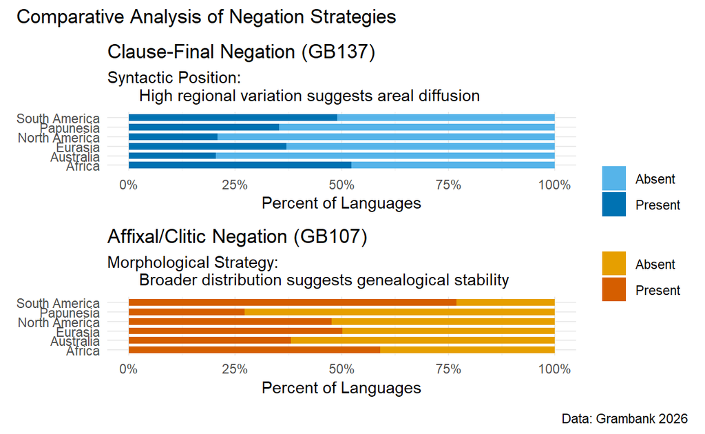

# Section 2: WALS Structural Correlation

In contrast to the binary granularity of Grambank, the WALS dataset allows for the investigation into the dependency between clausal symmetry (113A) and syntactic Position (143G).

Table 4: Areal Association: 113A vs. Macroarea

| Statistic | P-Value | DF | Method |
| --- | --- | --- | --- |
| 17.78634 | 0.0594703 | NA | Pearson’s Chi-squared test with simulated p-value |
| (based on 2000 replicates) |  |  |  |

Table 4: Areal Association: 1143G vs. Macroarea

| Statistic | P-Value | DF | Method |
| --- | --- | --- | --- |
| 24.72971 | 0.055972 | NA | Pearson’s Chi-squared test with simulated p-value |
| (based on 2000 replicates) |  |  |  |

# 2.1 Strategy vs. Word Order

The contingency table below maps the frequency of specific strategy-order pairings. A significant chi-squared result suggests that certain syntactic positions favor more complex grammatical pathways.

Table 5: Contingency Table: WALS 113A vs WALS 143G

| V-Neg | Neg-V |
| --- | --- |
| 0 | 112 |
| 1 | 49 |
| 1 | 125 |

Table 5: Chi-squared Test Results: Correlation between Strategy and Order

| Statistic | P-Value | DF | Method |
| --- | --- | --- | --- |
| 2.037003 | 0.6541729 | NA | Pearson’s Chi-squared test with simulated p-value |
| (based on 2000 replicates) |  |  |  |

The above Chi-squared results for the WALS data 113A and 143G reveals no statistically significant correlations. Unlike the regional clustering observed in the Grambank data, these results suggest that the choice between symmetric and asymmetric negation strategies is not strictly dictated by basic word orders or the position of the negative element.

The independence may indicate that these structural dimensions evolve through different typological pressures. As while a language may shift its negative position due to contact or changes in word-order, the internal symmetry of its negation system appears to remain as a distinct and independent structural trait.

# 2.2 Visualising Proportional Trends

While the previous Chi-squared test confirms a lack of statistical correlation, the following proportional plot allows for the inspection of how clausal symmetry (113A) is distributed across different syntactic positions (143G). Through this standardisation of frequencies to 100%, the relative prevalence of symmetric versus asymmetric negation strategies for both V-Neg and Neg-V word orders become observable.

The resulting distribution illustrates the structural diversity of negation, as it demonstrates that neither syntactic position (113A or 143G) constrains a language into a specific morphological pathway. Noticeably, however, the data does reveal that symmetric strategies are only present within the Neg-V category, therefore potentially suggesting that these features are generally governed by independent evolutionary typological pressures, despite certain morphological configurations that may be restricted to specific word-order environments.

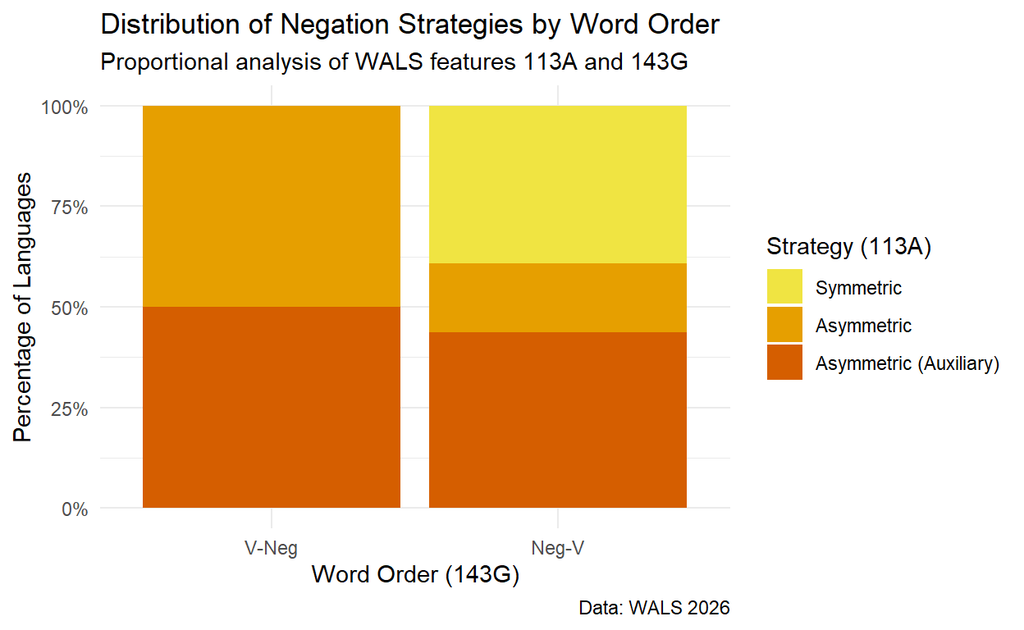

# Section 3: Comparing WALS and Grambank Datasets

To synthesize the previous findings, I plotted the global distributions of WALS 113A (Clausal symmetry), alongside Grambank GB137 (Clause-final negation). Mapping these features allows me to move beyond abstract percentages and observe the actual geographic densities of negation strategies. These comparison visualisations highlight how specific structural choices cluster in particular regions, thus providing a final layer of evidence for the areal and genealogical trends discussed throughout this analysis.

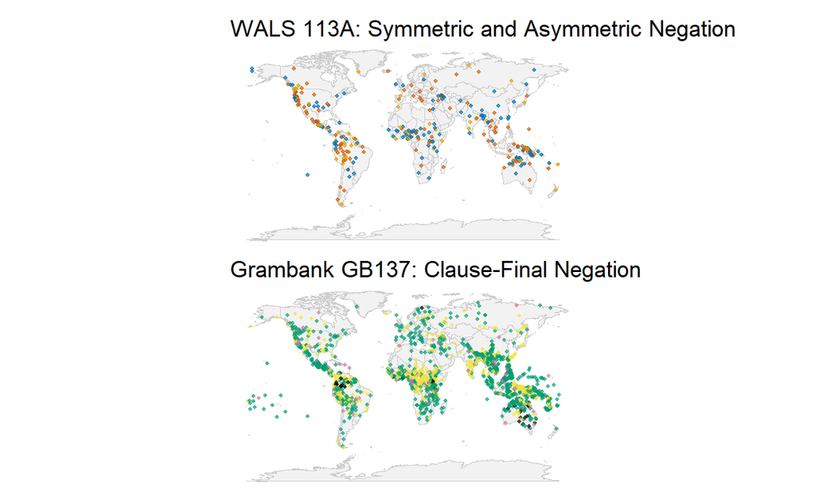

The comparison between the WALS and Grambank maps illustrates the complementary nature of each dataset. While the WALS map (above) captures a broad typological overview of clausal symmetry with a focus on categorical variety, the Grambank map (below) provides a more dense, binary snapshot of syntactic positioning. In combination, they reveal that certain regions are hot-spots for diverse negation strategies. These maps confirm that while negation is a universal linguistic requirement, its structural implementation is deeply tied to the geographic and historical context of the world’s language families.

NOTES:  
- Data retrieved from WALS and Grambank March 20, 2026  
- Colour-blind accessible colours used (Okabe-Ito)